# Early integration analysis notebook

Author

Joseph Oddy

# 1 Data loading/processing

The first steps in this notebook load the necessary libraries, source the data acquisition script, and process the data. This involves some separate processing of the different data modalities (e.g. scaling) before combining them into a single large matrix with the target variable (% of NK cells in sample) appended to this.

# 2 Nested cross-validation of random forest model

The model used here to test the early integration method is a random forest regression model. Nested cross-validation is used to assess the performance of the model, with an outer loop for performance assessment and an inner loop for hyperparameter tuning.

## 2.1 Model assessment

Five-fold cross-validation was specified for the “outer fold” (performance) assessment. The results are shown in Table 2 and Figure 1. The model has a very high R2, indicating that it explains the variance well. The RMSE is not as good, indicating that the estimates are a little off although they still explain the variance well.

**Model metrics - overall**

Table 1

Nested Random Forest Regression Metrics - Overall

| .metric | mean_estimate | median_estimate |
| --- | --- | --- |
| rmse | 0.127890356736238 | 0.123357896993322 |
| rsq | 0.987216234555595 | 0.989094538079748 |

**Model metrics - each fold**

Table 2

Nested Random Forest Regression Metrics

| .metric | .estimator | .estimate | id | id2 |
| --- | --- | --- | --- | --- |
| rmse | standard | 0.0940336301845818 | Repeat1 | Fold1 |
| rsq | standard | 0.99274704279659 | Repeat1 | Fold1 |
| rmse | standard | 0.127344595259446 | Repeat1 | Fold2 |
| rsq | standard | 0.996552182335943 | Repeat1 | Fold2 |
| rmse | standard | 0.148218760885322 | Repeat1 | Fold3 |
| rsq | standard | 0.996070452950656 | Repeat1 | Fold3 |
| rmse | standard | 0.216378188442847 | Repeat1 | Fold4 |
| rsq | standard | NA | Repeat1 | Fold4 |
| rmse | standard | 0.114471265353681 | Repeat1 | Fold5 |
| rsq | standard | 0.992671788393368 | Repeat1 | Fold5 |

[output cut: 40 more lines]

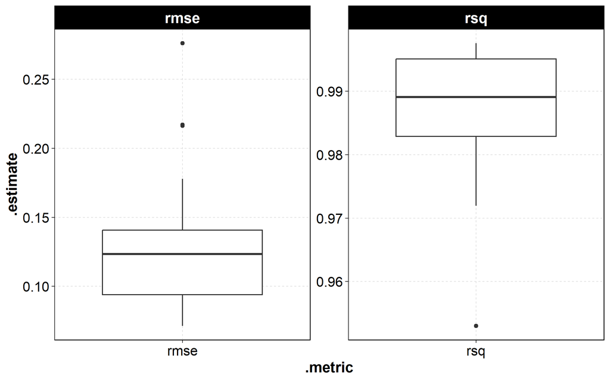

## 2.2 Final model - parameters

Table 3

Final model - selected parameters

| parameter | value |
| --- | --- |
| mtry | 5 |
| trees | 100 |
| min_n | 2 |

## 2.3 Feature importance

Having assessed the performance of the model, we can train a new model on all the data. We perform another grid-search and cross-validation to select the best hyperparameters from all the data. Feature importances are then extracted from this model that was trained on all the data. Importantly, this model is not used to assess the performance of the model, only for the feature importances.

Figure 2 shows the top 10 features with the greatest importance whereas Figure 3 shows the number of features from each modality that have a positive importance. Notably, the modalities with the greatest number of features represented here are the scRNA and O-link, indicating a potential bias due to their greater dimensionality.

**Ranked features**

Figure 2

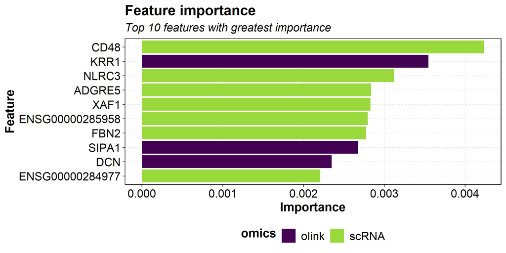

**Number of features from each modality**

Figure 3

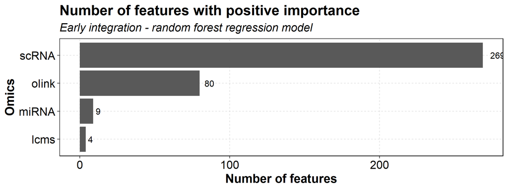

**Distribution of feature importances**

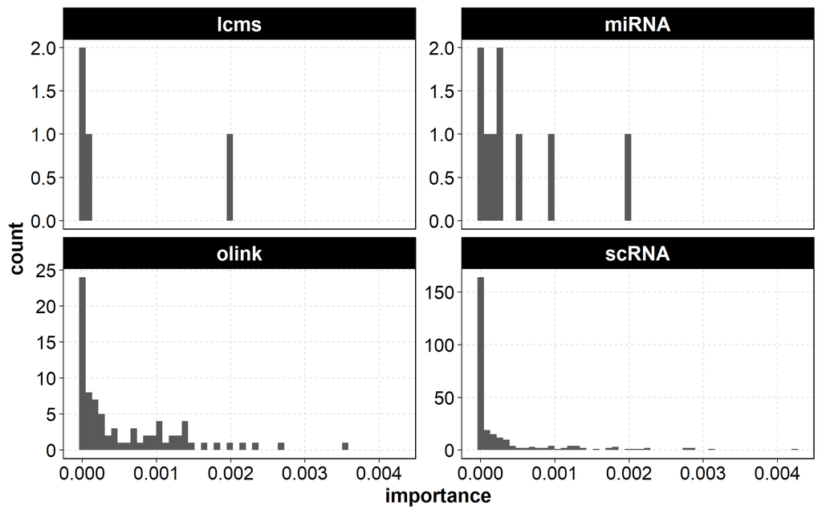

**Distribution of negative importances**

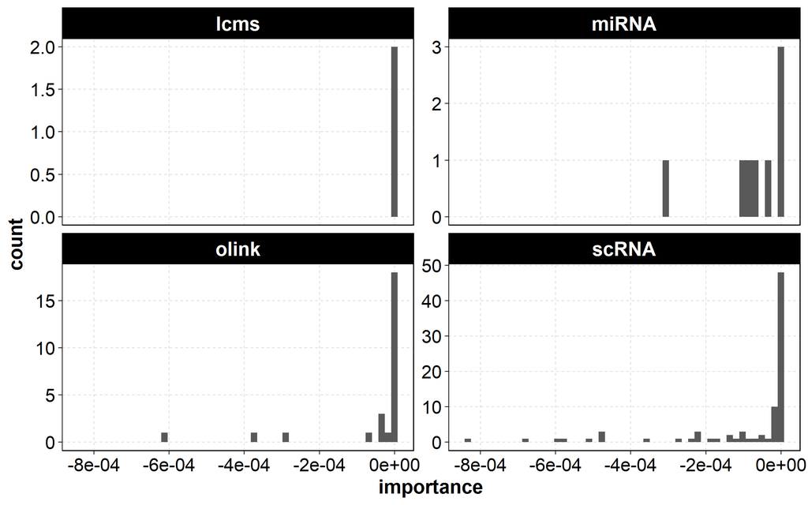